# Final Project: MHV68 Gene Expression in Wild-Type vs. Viral Cyclin-KO

Ashley Knox, Hayley Sparks, Sarah Stonedahl

Spring, 2017

## Overview

A murine fibroblast cell line (3T12) was infected with either a wild-type murine gammaherpesvirus (MHV68) or with a viral cyclin (v-cyclin) knock-out strain of the virus. After infection, RNA seq data was collected for both the host and viral genes to evaluate gene expression. We used the data for the viral genes to determine differences in expression between the wild-type and mutant MHV68 during infection.

## Step 1. Load packages and the data

```r
library(tidyverse)
library(knitr)
library(stringr)
library(cowplot)
library(RColorBrewer)
library(gtools)
library(readr)
All_genes_raw <- read_csv("~/R/final-projects/All_genes_raw.csv")
View(All_genes_raw)
```

## Step 2. Tidy the data

```r
select(All_genes_raw, 1:2, 4, 5, 7, 8) -> raw_data

colnames(raw_data) <- c("Gene.Num", "Gene.Name", "WT_1", "WT_2", "cyc_1", "cyc_2")

raw_data %>% gather(key, exp, WT_1:cyc_2) %>% separate(key, into = c('Treatment', 'rep'), sep = '_') %>% arrange(Gene.Num) -> tidy_data

tidy_data
```

```
#> # A tibble: 292 × 5
#>    Gene.Num Gene.Name Treatment   rep       exp
#>       <chr>     <chr>     <chr> <chr>     <dbl>
#> 1     gene0        M1        WT     1   222.511
#> 2     gene0        M1        WT     2   266.026
#> 3     gene0        M1       cyc     1   267.142
#> 4     gene0        M1       cyc     2   234.678
#> 5     gene1        M2        WT     1   358.988
#> 6     gene1        M2        WT     2   325.860
#> 7     gene1        M2       cyc     1   308.193
#> 8     gene1        M2       cyc     2   299.435
#> 9    gene10     ORF11        WT     1 19788.000
#> 10   gene10     ORF11        WT     2 18663.600
#> # ... with 282 more rows
```

## Step 3. Calculate average gene expression for wild-type and v-cyclin-KO MHV68-treated cells

```r
tidy_data %>% group_by(Gene.Num, Gene.Name, Treatment) %>% summarise(mean.exp = mean(exp), sd.exp = sd(exp)) %>% ungroup() -> mean_exp_data

mean_exp_data
```

```
#> # A tibble: 146 × 5
#>    Gene.Num Gene.Name Treatment   mean.exp     sd.exp
#>       <chr>     <chr>     <chr>      <dbl>      <dbl>
#> 1     gene0        M1       cyc   250.9100  22.955515
#> 2     gene0        M1        WT   244.2685  30.769752
#> 3     gene1        M2       cyc   303.8140   6.192841
#> 4     gene1        M2        WT   342.4240  23.425033
#> 5    gene10     ORF11       cyc 18096.5500 468.175400
#> 6    gene10     ORF11        WT 19225.8000 795.070865
#> 7    gene11     ORF12       cyc  2114.1850  80.249549
#> 8    gene11     ORF12        WT  2187.7850 155.952401
#> 9    gene12     ORF17       cyc  3942.6800 172.435060
#> 10   gene12     ORF17        WT  3985.9100 196.575685
#> # ... with 136 more rows
```

## Step 4. Calculate the fold-change in gene expression

```r
#Calculate fold change
mean_exp_data %>% select(1,2,3,4) %>% spread(Treatment, value = mean.exp) %>% mutate(fc.exp = (foldchange(cyc, WT))) %>% arrange(desc(fc.exp)) -> fc_exp_data

transform(fc_exp_data, Gene.Name = reorder(Gene.Name, order(fc.exp, decreasing = TRUE))) -> fc_exp_data
fc_exp_data
```

```
#>    Gene.Num Gene.Name         cyc          WT    fc.exp
#> 1    gene53     ORF60   8250.8350   6043.4400  1.365255
#> 2    gene70    ORF75A    200.2065    155.5895  1.286761
#> 3    gene37     ORF43   1016.9350    832.7665  1.221153
#> 4    gene31     ORF35   5671.2400   4845.0750  1.170516
#> 5    gene35     ORF39  10706.2500   9214.6600  1.161871
#> 6    gene30     ORF34   2187.3450   1890.2000  1.157203
#> 7    gene21     ORF25  26137.6500  22666.2500  1.153153
#> 8    gene38     ORF42   3658.2500   3178.2150  1.151039
#> 9     gene3        M4  15084.5500  13154.3000  1.146739
#> 10   gene56     ORF62   5977.9250   5225.5050  1.143990
#> 11    gene2        M3  75236.1500  66007.9500  1.139804
#> 12   gene32     ORF36   9736.4350   8624.6650  1.128906
#> 13   gene54     ORF59  37083.3500  33181.4000  1.117594
#> 14   gene50     ORF55   1881.9650   1713.0200  1.098624
```

[output cut: 59 more lines]

```r
head(fc_exp_data, 5) -> top5_up

tail(fc_exp_data, 5) -> top5_down
```

## Step 5. Graph the fold-change for the top and bottom 5 genes

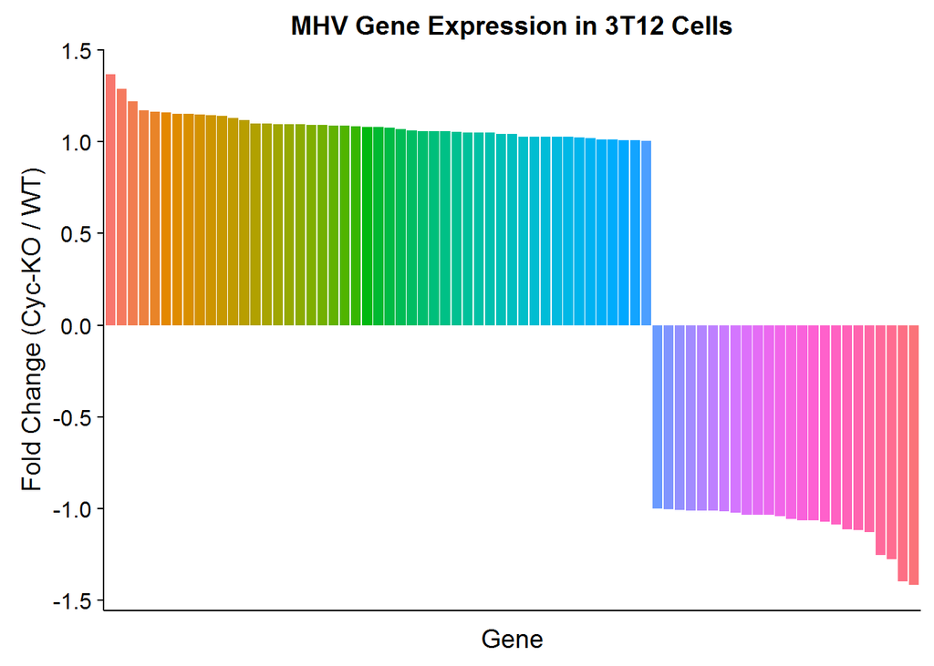

```r
#A graph showing the expression trend of all genes in the data set
ggplot(fc_exp_data, aes(x = Gene.Name, y = fc.exp, fill = Gene.Name)) + geom_bar(stat = "identity") + xlab("Gene") + ylab("Fold Change (Cyc-KO / WT)") + ggtitle("MHV Gene Expression in 3T12 Cells") + guides(fill = FALSE) + theme(axis.ticks.x=element_blank(), axis.text.x=element_blank())
```

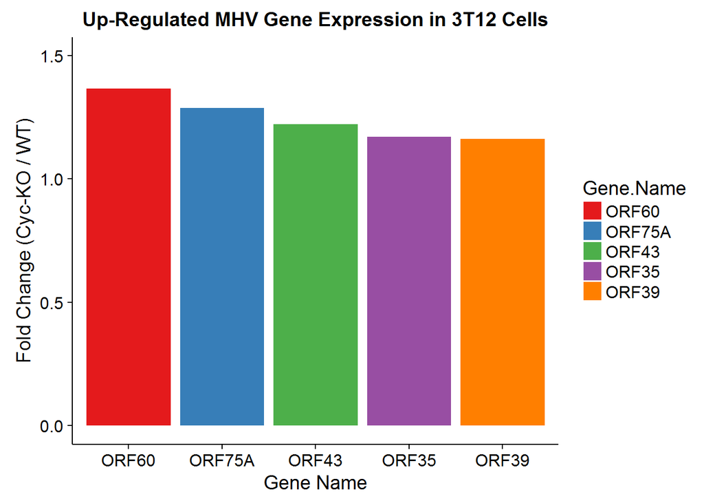

```r
#Top 5 up-regulated genes
ggplot(top5_up, aes(x = Gene.Name, y = fc.exp, fill = Gene.Name)) + geom_bar(stat = "identity") + scale_y_continuous(limits = c(0, 1.5)) + xlab("Gene Name") + ylab("Fold Change (Cyc-KO / WT)") + ggtitle("Up-Regulated MHV Gene Expression in 3T12 Cells") + scale_fill_brewer(type = "qual", palette = 6, direction = 1)
```

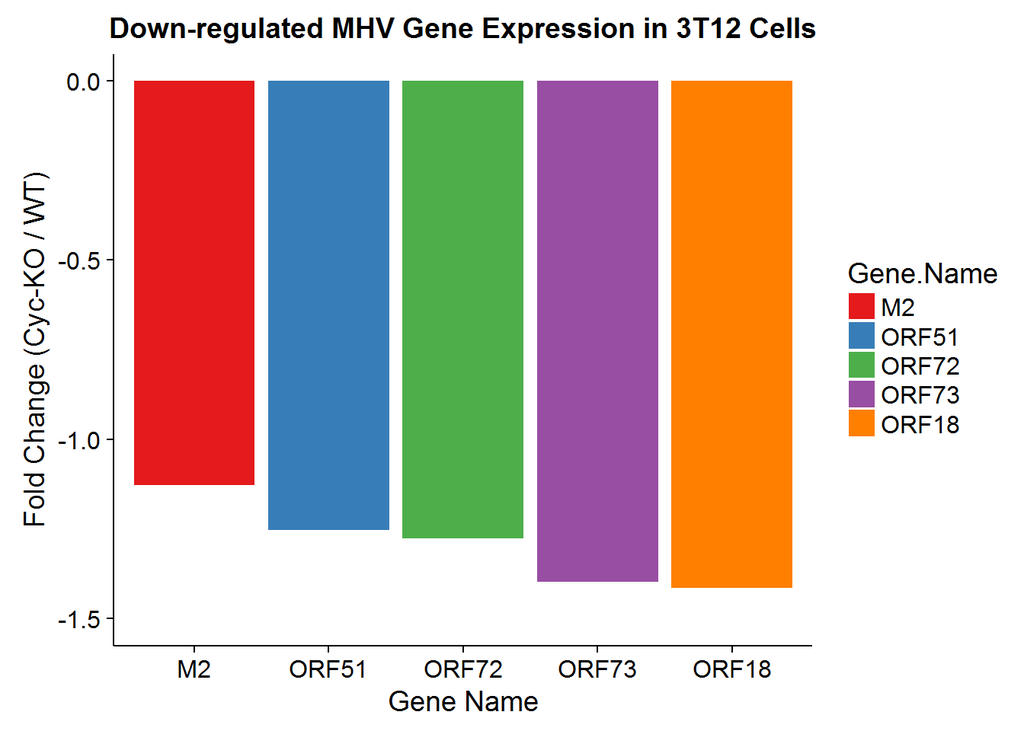

```r
#Top 5 down-regulated genes
ggplot(top5_down, aes(x = Gene.Name, y = fc.exp, fill = Gene.Name)) + geom_bar(stat = "identity") + xlab("Gene Name") + ylab("Fold Change (Cyc-KO / WT)") + scale_y_continuous(limits = c(-1.5, 0)) + ggtitle("Down-regulated MHV Gene Expression in 3T12 Cells") + scale_fill_brewer(type = "qual", palette = 6, direction = 1)
```

## Summary

The data we’ve analyzed here contains the gene expression data for murine gammaherpesvirus during infection of a murine fibroblast cell line (3T12). The cells were treated with either the wild-type virus or a viral-cyclin knock-out virus. We calcuated the fold-change of gene expression in the mutant virus over the wild-type virus. The average fold-change is 0.3704713 with a standard deviation of 1.0360658. The maximum fold change is 1.3652547 for ORF60 and the minimum is -1.4151777, which is ORF18. Given that previous experiments have shown that viral cyclin is not required for lytic infection, it is interesting that there are several genes that are differentially expressed between the WT and V-cyclin KO viruses during infection. A couple of the most down-regulated genes are ORF18, which is a viral transcription factor required for transcription of late genes, and ORF73 (a.k.a LANA), which tethers the viral genome to the host chromosome during latency and regulates host gene expression. Interestingly, these genes are more down-regulated than the v-cyclin (ORF72) itself. These results indicate that the viral cyclin of this gammaherpesvirus may play a previously unknown role in viral replication during lytic infection.